# Assignment 3

Boopathy

2024-08-27

#1)In this problem, you will develop a model to predict whether a given car gets high or low gas mileage based on the Auto data set.

```r
#rm(list=ls())

library(ISLR)
```

```r
library(ISLR2)
library(MASS)
library(class)
summary(Auto)
```

```
##       mpg          cylinders      displacement     horsepower        weight
##  Min.   : 9.00   Min.   :3.000   Min.   : 68.0   Min.   : 46.0   Min.   :1613
##  1st Qu.:17.00   1st Qu.:4.000   1st Qu.:105.0   1st Qu.: 75.0   1st Qu.:2225
##  Median :22.75   Median :4.000   Median :151.0   Median : 93.5   Median :2804
##  Mean   :23.45   Mean   :5.472   Mean   :194.4   Mean   :104.5   Mean   :2978
##  3rd Qu.:29.00   3rd Qu.:8.000   3rd Qu.:275.8   3rd Qu.:126.0   3rd Qu.:3615
##  Max.   :46.60   Max.   :8.000   Max.   :455.0   Max.   :230.0   Max.   :5140
##
##   acceleration        year           origin                      name
##  Min.   : 8.00   Min.   :70.00   Min.   :1.000   amc matador       :  5
##  1st Qu.:13.78   1st Qu.:73.00   1st Qu.:1.000   ford pinto        :  5
##  Median :15.50   Median :76.00   Median :1.000   toyota corolla    :  5
##  Mean   :15.54   Mean   :75.98   Mean   :1.577   amc gremlin       :  4
##  3rd Qu.:17.02   3rd Qu.:79.00   3rd Qu.:2.000   amc hornet        :  4
##  Max.   :24.80   Max.   :82.00   Max.   :3.000   chevrolet chevette:  4
##                                                  (Other)           :365
```

```r
attach(Auto)
```

```r
m<-mean(Auto$mpg)
mpg01<-ifelse(Auto$mpg>m,yes=1,no=0)
Auto<-data.frame(Auto,mpg01)
```

#b)Explore the data graphically in order to investigate the association between mpg01 and the other features. Which of the other features seem most likely to be useful in predicting mpg01? Scatterplots and boxplots may be useful tools to answer this question. Describe your findings.

```r
cor(Auto[,-9])
```

```
##                     mpg  cylinders displacement horsepower     weight
## mpg           1.0000000 -0.7776175   -0.8051269 -0.7784268 -0.8322442
## cylinders    -0.7776175  1.0000000    0.9508233  0.8429834  0.8975273
## displacement -0.8051269  0.9508233    1.0000000  0.8972570  0.9329944
## horsepower   -0.7784268  0.8429834    0.8972570  1.0000000  0.8645377
## weight       -0.8322442  0.8975273    0.9329944  0.8645377  1.0000000
## acceleration  0.4233285 -0.5046834   -0.5438005 -0.6891955 -0.4168392
## year          0.5805410 -0.3456474   -0.3698552 -0.4163615 -0.3091199
## origin        0.5652088 -0.5689316   -0.6145351 -0.4551715 -0.5850054
## mpg01         0.8408220 -0.7340366   -0.7355848 -0.6494910 -0.7445033
##              acceleration       year     origin      mpg01
## mpg             0.4233285  0.5805410  0.5652088  0.8408220
## cylinders      -0.5046834 -0.3456474 -0.5689316 -0.7340366
## displacement   -0.5438005 -0.3698552 -0.6145351 -0.7355848
## horsepower     -0.6891955 -0.4163615 -0.4551715 -0.6494910
## weight         -0.4168392 -0.3091199 -0.5850054 -0.7445033
## acceleration    1.0000000  0.2903161  0.2127458  0.3209701
## year            0.2903161  1.0000000  0.1815277  0.4510104
## origin          0.2127458  0.1815277  1.0000000  0.5192282
## mpg01           0.3209701  0.4510104  0.5192282  1.0000000
```

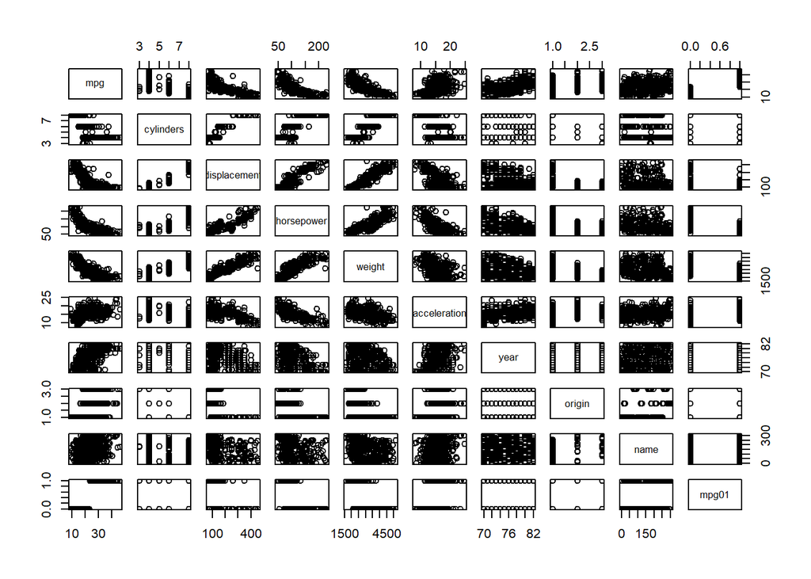

```r
pairs(Auto)
```

#c)Split the data into a training set and a test set.

```r
Auto <- data.frame(mpg01, apply(cbind(cylinders, weight, displacement, horsepower, acceleration),
                                2, scale), year)
```

```r
set.seed(0)
tn=0.3
sub<-sample(1:nrow(Auto),round(nrow(Auto)*tn),rep=FALSE)
data_train<-Auto[-sub,]
data_test<-Auto[sub,]
dim(data_train)
```

```
## [1] 274   7
```

```r
dim(data_test)
```

```
## [1] 118   7
```

#d)Perform LDA on the training data in order to predict mpg01 using the variables that seemed most associated with mpg01 in (b). What is the test error of the model obtained?

```r
LDA<-lda(mpg01~cylinders+weight+displacement+horsepower,data=data_train)
LDA_pred<-predict(LDA,data_test)
mean(LDA_pred$class!=data_test$mpg01)
```

```
## [1] 0.1440678
```

```r
table(LDA_pred$class,data_test$mpg01)
```

```
##
##      0  1
##   0 51  5
##   1 12 50
```

#e)Perform QDA on the training data in order to predict mpg01 using the variables that seemed most associated with mpg01 in (b). What is the test error of the model obtained?

```r
QDA<-qda(mpg01~cylinders+weight+displacement+horsepower,data=data_train)
QDA_pred<-predict(QDA,data_test)
mean(QDA_pred$class!=data_test$mpg01)
```

```
## [1] 0.1355932
```

```r
table(QDA_pred$class,data_test$mpg01)
```

```
##
##      0  1
##   0 54  7
##   1  9 48
```

#f)Perform logistic regression on the training data in order to predict mpg01 using the variables that seemed most associated with mpg01 in (b). What is the test error of the model obtained?

```r
LR<-glm(mpg01~cylinders+weight+displacement+horsepower,data=data_train,family = binomial)
LR_prob<-predict(LR,data_test,type="response")
LR_pred<-rep(0,length(LR_prob))
LR_pred[LR_prob>0.5]<-1
mean(LR_pred!=data_test$mpg01)
```

```
## [1] 0.1186441
```

#g)Perform KNN on the training data, with several values of K, in order to predict mpg01. Use only the variables that seemed most associated with mpg01 in (b). What test errors do you obtain? Which value of K seems to perform the best on this data set?

```r
knn_pred1 <-knn(data_train[,-9], data_test[,-9], data_train$mpg01, k = 1)
mean(knn_pred1!=data_test$mpg01)
```

```
## [1] 0.01694915
```

```r
knn_pred2 <-knn(data_train[,-9], data_test[,-9], data_train$mpg01, k = 2)
mean(knn_pred2!=data_test$mpg01)
```

```
## [1] 0.03389831
```

```r
knn_pred3 <-knn(data_train[,-9], data_test[,-9], data_train$mpg01, k = 3)
mean(knn_pred3!=data_test$mpg01)
```

```
## [1] 0.02542373
```

```r
knn_pred4 <-knn(data_train[,-9], data_test[,-9], data_train$mpg01, k = 5)
mean(knn_pred4!=data_test$mpg01)
```

```
## [1] 0.01694915
```